# HYUNJAE's Blog

2019-11-19

# 딥러닝 1단계 : 신경망과 딥러닝

2019-11-19

# 1. 딥러닝 소개

## 1강 - 환영합니다.

- keyword : Deep learning, Neural Network, CNN, RNN
- 학습내용 :
  1. Deep Learning을 포함한 새로운 Neural Network를 어떻게 설계하는지, 어떻게 데이터를 가지고 학습 하는지
  2. NN작동원리 및 하이퍼 파라미터 조율, bias와 variance는 어떻게 차즌ㄴ지, 최적화 알고리즘은 무어잇이 있는지
  3. ML 프로젝트를 어떻게 설계해야하는지
  4. 이미지에 적용되는 CNN모델 구축 방법

## 2강 - 신경망은 무엇인가?

- 학습목표 : 신경망(Neural Network)이 무엇인지
- keyword : 신경망(Neural Network)
- 학습내용 :
  1. 신경망이란 입력(x)와 출력(y)를 매칭해주는 함수를 찾는 과정
  2. 충분한 데이터가 주어지면 더 잘 알아낼수 있음
  3. 해당 뉴런에 관계없는 입력값이라도 입력으로 넣어주어야함. 관계 여부는 신경망이 학습하면서 알아서 조절
- 강의 내용 :
  - 신경망의 뉴런 : X -> 뉴런 -> Y
  - 더 큰 신경망은 더 많은 뉴런들로 구성됨
  - 뉴런을 쌓음으로써 더큰 신경망이 됨
  - 은닉 유닛
  - 뉴런? X를 입력받아 선형 함수를 계산하고 Y를 예측
  - ReLu - Rectified Linear Unit : rectify는 0과 결과 값 중 큰 값을 취하라는 뜻
  - 어떤 신경망을 만들고 싶든지, 어떤 계산을 하고 싶든지 신경망의 입력층(input layer)과 중앙에 있는 층(은닉층)은 조밀하게 연결되어 있음
  - 모든 입력 특성들은 중앙에 있는 원 모두에 연결되어 있기 때문에 충분한 양의 x와 y를 훈련 예제로 준다면 신경망은 x를 y로 연결하는 함수를 알아내는데 뛰어날 것임

## 3강 - 신경망을 이용한 지도학습

- 학습목표 : 지도학습(Supervised Learnig)이 무엇인지
- keyword : 지도학습(Supervised Learnig), 입력(Input), 출력(Output), 구조적 데이터(Structured Data), 비구조적 데이터(Unstructured Data)
- 학습내용 :
  1. 머신러닝의 방법은 지도 학습, 비지도 학습 등 여러가지 종류가 있음
  2. 지도 학습이란 정답이 주어져있는 데이터를 사용하여 컴퓨터를 학습시키는 방법
  3. 신경망을 이용해 지도 학습을 구현할 수 있음
  4. 분야에 따라 적용되는 신경망이 다름 ex)이미지 분류를 위해 CNN, 음성을 텍스트로 변화시키기 위해 RNN 사용
  5. 구조적 및 비구조적 데이터를 신경망을 사용하여 예측
  6. 구조적 데이터 : 데이터베이스로 표현된 데이터, 정보의 특성이 잘 정의되어 있음
  7. 비구조적 뎅치터 : 이미지, 오디오와 같이 특징적인 값을 추출하기 어려운 형태의 데이터, 딥러닝으로 컴퓨터가 비구조적 데이터를 인식할 수 있게 됨.
- 강의내용 :
  - 지금까지 대부분의 신경망을 통해 만들어진 경제적인 가치들은 머신러닝의 한 종류인 지도학습을 통해 계산됨
  - 지도학습에서는 입력 X와 출력 Y에 매핑되는 함수를 학습하려함 예시 - 주택가격, 온라인 광고, 컴퓨터 비전, 음성인식, 기계 번역, 자율주행 등
  - 신경망을 통한 많은 값들의 생성은 어떤 문제를 해결하기 위한 적절한 X와 Y를 통해 이루어지고, 자율 주행 같은 더 큰 시스템에 지도학습 요소들이 적합하게 함.
  - 조금씩 다른 신경망들은 서로 다른 적절한 응용분야에 적용됨
  - 표준신경망, CNN, 합성곱 신경망, 주로 1차원의 시계열 데이터로 나타나는 시퀀스 데이터 - RNN,등
  - 구조적 데이터(Structured Data) : 기본적으로 데이터베이스로 표현된 데이터
  - 비구조적 데이터(Unstructured Data) : 오디오, 이미지, 텍스트 등 구조적 데이터 보다 컴퓨터가 작업하기 훨씬 어려움
  - 신경망에서 발생하는 많은 경제적인 이익은 광고 시스템이나 사용자 맞춤 추천 같은 구조적 데이터에서 오는 경우가 많음
  - 신경망은 지도학습으로 변환할 수 있고, 거대한 수익을 창출할 수 있음
  - 신경망의 기본적인 기술적 아이디어들은 몇십 년간 존재해 왔음

## 4강 - 왜 딥러닝이 뜨고 있을가요?

- 학습목표 : 최근 딥러닝이 강력한 도구로 부상해는지 알 수 있음
- keyword : 데이터 크기(Scale of Data), 컴퓨팅 성능 향상(Computation), 알고리즘(Algorithm)
- 학습내용 :
  1. 깊은 모델 일수록 더 많은 데이터가 필요하며, 이는 곧 좋은 퍼포먼스로 나타남
  2. 최근 딥러닝이 강력한 도구로 부상한 이유는 아래의 3가지 요인들로 인해 딥러닝 성능이 향상되었기 때문
  - 데이터 양 증가
  - 컴퓨터 성능 향상
  - 알고리즘의 개선
    - Sigmoid 함수가 아닌 ReLU 함수를 사용함으로 Gradient 소멸 문제 해결

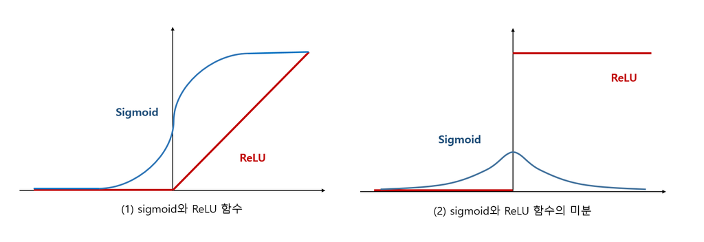

2019-11-19

Deep Learning

# 딥러닝 1단계 : 신경망과 딥러닝

# 1. 딥러닝 소개

## 1강 - 환영합니다.

- keyword : Deep learning, Neural Network, CNN, RNN
- 학습내용 :  
  1) Deep Learning을 포함한 새로운 Neural Network를 어떻게 설계하는지, 어떻게 데이터를 가지고 학습 하는지  
  2) NN작동원리 및 하이퍼 파라미터 조율, bias와 variance는 어떻게 차즌ㄴ지, 최적화 알고리즘은 무어잇이 있는지  
  3) ML 프로젝트를 어떻게 설계해야하는지  
  4) 이미지에 적용되는 CNN모델 구축 방법

## 2강 - 신경망은 무엇인가?

- 학습목표 : 신경망(Neural Network)이 무엇인지
- keyword : 신경망(Neural Network)
- 학습내용 :  
  1) 신경망이란 입력(x)와 출력(y)를 매칭해주는 함수를 찾는 과정  
  2) 충분한 데이터가 주어지면 더 잘 알아낼수 있음  
  3) 해당 뉴런에 관계없는 입력값이라도 입력으로 넣어주어야함. 관계 여부는 신경망이 학습하면서 알아서 조절
- 강의 내용 :
  - 신경망의 뉴런 : X -> 뉴런 -> Y
    - 더 큰 신경망은 더 많은 뉴런들로 구성됨
    - 뉴런을 쌓음으로써 더큰 신경망이 됨
    - 은닉 유닛
  - 뉴런? X를 입력받아 선형 함수를 계산하고 Y를 예측
  - ReLu - Rectified Linear Unit : rectify는 0과 결과 값 중 큰 값을 취하라는 뜻
  - 어떤 신경망을 만들고 싶든지, 어떤 계산을 하고 싶든지 신경망의 입력층(input layer)과 중앙에 있는 층(은닉층)은 조밀하게 연결되어 있음
  - 모든 입력 특성들은 중앙에 있는 원 모두에 연결되어 있기 때문에 충분한 양의 x와 y를 훈련 예제로 준다면 신경망은 x를 y로 연결하는 함수를 알아내는데 뛰어날 것임

## 3강 - 신경망을 이용한 지도학습

- 학습목표 : 지도학습(Supervised Learnig)이 무엇인지
- keyword : 지도학습(Supervised Learnig), 입력(Input), 출력(Output), 구조적 데이터(Structured Data), 비구조적 데이터(Unstructured Data)
- 학습내용 :  
  1) 머신러닝의 방법은 지도 학습, 비지도 학습 등 여러가지 종류가 있음  
  2) 지도 학습이란 정답이 주어져있는 데이터를 사용하여 컴퓨터를 학습시키는 방법  
  3) 신경망을 이용해 지도 학습을 구현할 수 있음  
  4) 분야에 따라 적용되는 신경망이 다름  
  ex)이미지 분류를 위해 CNN, 음성을 텍스트로 변화시키기 위해 RNN 사용  
  5) 구조적 및 비구조적 데이터를 신경망을 사용하여 예측  
  6) 구조적 데이터 : 데이터베이스로 표현된 데이터, 정보의 특성이 잘 정의되어 있음  
  7) 비구조적 데이터 : 이미지, 오디오와 같이 특징적인 값을 추출하기 어려운 형태의 데이터, 딥러닝으로 컴퓨터가 비구조적 데이터를 인식할 수 있게 됨.
- 강의내용 :
  - 지금까지 대부분의 신경망을 통해 만들어진 경제적인 가치들은 머신러닝의 한 종류인 지도학습을 통해 계산됨
  - 지도학습에서는 입력 X와 출력 Y에 매핑되는 함수를 학습하려함  
    예시 - 주택가격, 온라인 광고, 컴퓨터 비전, 음성인식, 기계 번역, 자율주행 등
  - 신경망을 통한 많은 값들의 생성은 어떤 문제를 해결하기 위한 적절한 X와 Y를 통해 이루어지고, 자율 주행 같은 더 큰 시스템에 지도학습 요소들이 적합하게 함.
  - 조금씩 다른 신경망들은 서로 다른 적절한 응용분야에 적용됨
  - 표준신경망, CNN, 합성곱 신경망, 주로 1차원의 시계열 데이터로 나타나는 시퀀스 데이터 - RNN,등
  - 구조적 데이터(Structured Data) : 기본적으로 데이터베이스로 표현된 데이터
  - 비구조적 데이터(Unstructured Data) : 오디오, 이미지, 텍스트 등 구조적 데이터 보다 컴퓨터가 작업하기 훨씬 어려움
  - 신경망에서 발생하는 많은 경제적인 이익은 광고 시스템이나 사용자 맞춤 추천 같은 구조적 데이터에서 오는 경우가 많음
  - 신경망은 지도학습으로 변환할 수 있고, 거대한 수익을 창출할 수 있음
  - 신경망의 기본적인 기술적 아이디어들은 몇십 년간 존재해 왔음

## 4강 - 왜 딥러닝이 뜨고 있을가요?

- 학습목표 : 최근 딥러닝이 강력한 도구로 부상해는지 알 수 있음
- keyword : 데이터 크기(Scale of Data), 컴퓨팅 성능 향상(Computation), 알고리즘(Algorithm)
- 학습내용 :  
  1) 깊은 모델 일수록 더 많은 데이터가 필요하며, 이는 곧 좋은 퍼포먼스로 나타남  
  2) 최근 딥러닝이 강력한 도구로 부상한 이유는 아래의 3가지 요인들로 인해 딥러닝 성능이 향상되었기 때문
  - 데이터 양 증가
    - 컴퓨터 성능 향상
    - 알고리즘의 개선
      - Sigmoid 함수가 아닌 ReLU 함수를 사용함으로 Gradient 소멸 문제 해결

[figure not shown]

    - Sigmoid는 왼쪽, 오른쪽 끝으로 가면 미분값이 0이 되기 때문에 Gradient가 소멸하는 문제가 발생, ReLU 함수를 사용하므로 문제를 해결할 수 있음.